# Homework5

Lia

2023-11-16

# 1 Jimmy’s comments!

Good job! I was unfamiliar with the `boots` package so was interesting to see it be used. I’m a bit unsure how the algorithm works out compared to a general for loop, would like to see how it works out under the hood! I’d like to see some more comments throughout the code just because it was a bit of a situation to run and figure out. What’s the rationale behind the function you create for instance?

# 2 Bootstrapping Standard Erros and CIs for Linear Models.

Load the packages first.

```r
library(curl)
library(dplyr)
library(boot) # what's this package about? - Jimmy
```

## 2.1 Challenge 1

**Description:** Using the “KamilarAndCooperData.csv” dataset, run a linear regression looking at log(HomeRange_km2) in relation to log(Body_mass_female_mean) and report your β coeffiecients (slope and intercept).

Read the file.

```r
f <- curl("https://raw.githubusercontent.com/fuzzyatelin/fuzzyatelin.github.io/master/AN588_Fall21/KamilarAndCooperData.csv")
KC <- read.csv(f, header=TRUE, sep=",", stringsAsFactors=FALSE) %>% filter(!is.na(HomeRange_km2)) %>% filter(!is.na(Body_mass_female_mean))
# Smart to filter out na's now! I think you only need one filter() statement though -Jimmy
```

Modeling.

```r
lHR <- log(KC$HomeRange_km2) # I'm not sure I'd initialize all these variables just since it could be a bit confusing what's going on like 2 months removed from a project, "l" means both log and linear here too  - Jimmy
lBmfm <- log(KC$Body_mass_female_mean)
lmod <- lm(lHR ~ lBmfm, data=KC)
summary(lmod)
```

```
##
## Call:
## lm(formula = lHR ~ lBmfm, data = KC)
##
## Residuals:
##     Min      1Q  Median      3Q     Max
## -3.3929 -0.9433 -0.0126  1.0944  3.6826
##
## Coefficients:
##             Estimate Std. Error t value Pr(>|t|)
## (Intercept) -9.44123    0.67293  -14.03   <2e-16 ***
## lBmfm        1.03643    0.08488   12.21   <2e-16 ***
## ---
## Signif. codes:  0 '***' 0.001 '**' 0.01 '*' 0.05 '.' 0.1 ' ' 1
##
## Residual standard error: 1.423 on 135 degrees of freedom
## Multiple R-squared:  0.5248, Adjusted R-squared:  0.5213
## F-statistic: 149.1 on 1 and 135 DF,  p-value: < 2.2e-16
```

```r
coeffs <- lmod$coefficients
coeffs
```

```
## (Intercept)       lBmfm
##   -9.441231    1.036432
```

## 2.2 Challenge 2

**Description:** Then, use bootstrapping to sample from your data 1000 times with replacement, each time fitting the same model and calculating the same coefficients. This generates a sampling distribution for each β coefficient.

```r
set.seed(123)
fun <- function(formula, data, indices) {
  d <- data[indices, ]
  fit <- lm(formula, data=d) # I'm a bit confused on what's going on with this function - Jimmy
  return(coef(fit)) # i've never used boot() before is this necessary for getting that to work? - Jimmy
}
reps <- boot(data=KC, statistic=fun, R=1000, formula=log(HomeRange_km2) ~ log(Body_mass_female_mean))
reps
```

```
##
## ORDINARY NONPARAMETRIC BOOTSTRAP
##
##
## Call:
## boot(data = KC, statistic = fun, R = 1000, formula = log(HomeRange_km2) ~
##     log(Body_mass_female_mean))
##
##
## Bootstrap Statistics :
##      original       bias    std. error
## t1* -9.441231  0.030206507  0.58297075
## t2*  1.036432 -0.004445936  0.07553405
```

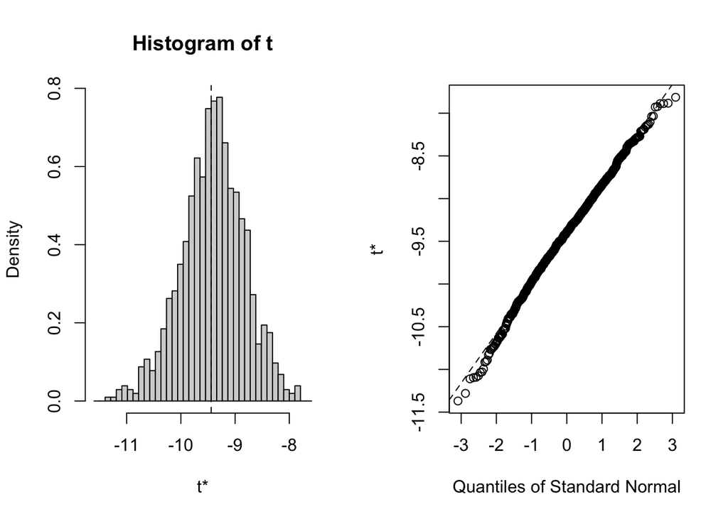

```r
plot(reps) # what is t? What is this a measure of? - Jimmy
```

```r
confint(lmod, level=0.95)
```

```
##                   2.5 %    97.5 %
## (Intercept) -10.7720889 -8.110374
## lBmfm         0.8685707  1.204292
```

```r
boot.ci(reps, type="bca", index=1) # I think when you do boot.ci you end up bootstrapping twice - Jimmy
```

```
## BOOTSTRAP CONFIDENCE INTERVAL CALCULATIONS
## Based on 1000 bootstrap replicates
##
## CALL :
## boot.ci(boot.out = reps, type = "bca", index = 1)
##
## Intervals :
## Level       BCa
## 95%   (-10.766,  -8.372 )
## Calculations and Intervals on Original Scale
```

```r
boot.ci(reps, type="bca", index=2) # I think you just need to do confint() here - Jimmy
```

```
## BOOTSTRAP CONFIDENCE INTERVAL CALCULATIONS
## Based on 1000 bootstrap replicates
##
## CALL :
## boot.ci(boot.out = reps, type = "bca", index = 2)
##
## Intervals :
## Level       BCa
## 95%   ( 0.898,  1.212 )
## Calculations and Intervals on Original Scale
```

**Question 1:** How does the former compare to the SE estimated from your entire dataset using the formula for standard error implemented in lm()?

**Answer:** SDE of bootstrapping β coefficients are 0.58297075 and 0.07553405. It looks better than 0.67293 and 0.08488 which comes from the model.

**Question 2:** How does the latter compare to the 95% CI estimated from your entire dataset?

**Answer:** In the bootstrapped method, intercept is -10.766 and -8.372, with slope of 0.898 and 1.212. In the non-bootstrapped method, intercept is -10.7720889 and -8.110374, with slope of 0.8685707 and 1.204292. the intercept in the bootstrapped method looks tighter.